# Edelweiss EDA & Modelling - Part 2

## 6. Extreme Gradient Boost Regressor Using All Features

```python
include=['log_wap','mm_cluster','dev_cluster','b1','b2','b3','b4','b5','b6','b7','b8','bp1','bp3','bp4','bp5','bp6','bp7','bp8','bp48','bp58','min_size','max_size','size_rv','unit_type','construction_status','proj_bedrooms_clean','proj_launched_units','launch_year','size_range','V1','V2','V3','V4','V5','V6','V7','V8','V9','V10','V11','V12','V13','V14','V15','V16','V17','V18','V19','V20','V21','V22','V23','V24','V25']
df3=pd.DataFrame(df1[include])

df3['launch_year']=df3['launch_year'].astype('int')
for i in ['unit_type','construction_status','proj_bedrooms_clean']: # Label-encoding of amenities features
    label_encoder(df3, i)

df3.head()
```

|  | log_wap | mm_cluster | dev_cluster | b1 | b2 | b3 | b4 | b5 | b6 | b7 | ... | V16 | V17 | V18 | V19 | V20 | V21 | V22 | V23 | V24 | V25 |
| --- | --- | --- | --- | --- | --- | --- | --- | --- | --- | --- | --- | --- | --- | --- | --- | --- | --- | --- | --- | --- | --- |
| 0 | 9.579418 | 6 | 16 | 106 | 5 | 0 | 0 | 0 | 0 | 0 | ... | -0.422871 | -0.789669 | -0.659173 | 0.189961 | 0.335592 | 1.264041 | 0.054089 | -0.131723 | -0.580872 | 0.412611 |
| 1 | 9.545526 | 6 | 16 | 0 | 98 | 52 | 0 | 0 | 0 | 0 | ... | -0.056276 | -0.577943 | -0.373556 | -0.023348 | 0.538932 | 0.988884 | -0.303059 | 0.348402 | -0.405855 | 0.458890 |
| 2 | 9.545526 | 6 | 16 | 0 | 98 | 52 | 0 | 0 | 0 | 0 | ... | -0.055074 | -0.553753 | -0.389509 | -0.025317 | 0.572751 | 1.003029 | -0.347910 | 0.379972 | -0.367028 | 0.492925 |
| 3 | 9.461644 | 6 | 3 | 107 | 13 | 0 | 0 | 0 | 0 | 0 | ... | -0.174178 | -0.400852 | -0.209210 | -0.201405 | 0.652291 | 1.168787 | 0.021800 | 0.150187 | -0.344659 | 0.357670 |
| 4 | 9.739884 | 6 | 11 | 1 | 22 | 10 | 0 | 0 | 0 | 0 | ... | -0.063372 | -0.468529 | -0.364467 | -0.108515 | 0.692411 | 1.022727 | -0.269232 | 0.352715 | -0.367375 | 0.468766 |

5 rows × 54 columns

```python
dependent = 'log_wap'
independent = df3.columns != dependent
x1 = df3.loc[:,independent]
y1 = df3[dependent]
x1_train, x1_test, y1_train, y1_test = train_test_split(x1, y1, random_state=8)

xg_reg_all=xgb.XGBRegressor(base_score=0, objective='reg:linear',n_estimators=170,learning_rate=0.065,reg_alpha=3)
xg_reg_all.fit(x1_train,y1_train)
```

```
XGBRegressor(base_score=0, booster='gbtree', colsample_bylevel=1,
       colsample_bytree=1, gamma=0, learning_rate=0.065, max_delta_step=0,
       max_depth=3, min_child_weight=1, missing=None, n_estimators=170,
       n_jobs=1, nthread=None, objective='reg:linear', random_state=0,
       reg_alpha=3, reg_lambda=1, scale_pos_weight=1, seed=None,
       silent=True, subsample=1)
```

```python
# cross validate
scores_xgreg_all = cross_validate(xg_reg_all, x1_train, y1_train, cv=8,
                        return_train_score=True,
                        return_estimator=False)
scores_xgreg_all = pd.DataFrame(scores_xgreg_all)
scores_xgreg_all
```

|  | fit_time | score_time | test_score | train_score |
| --- | --- | --- | --- | --- |
| 0 | 0.516828 | 0.000000 | 0.891895 | 0.921607 |
| 1 | 0.485654 | 0.000000 | 0.887290 | 0.923824 |
| 2 | 0.485653 | 0.015622 | 0.893273 | 0.922424 |
| 3 | 0.485827 | 0.000000 | 0.903565 | 0.922005 |
| 4 | 0.485802 | 0.015621 | 0.919859 | 0.922331 |
| 5 | 0.493963 | 0.010116 | 0.893503 | 0.922651 |
| 6 | 0.494465 | 0.010105 | 0.901874 | 0.923984 |
| 7 | 0.484554 | 0.000000 | 0.885221 | 0.923881 |

```python
print('Mean Test Score XGBoost Regressor using all features: ', scores_xgreg_all ['test_score'].mean())
print('Mean Train Score XGBoost Regressor using all features: ', scores_xgreg_all ['train_score'].mean())
```

```
Mean Test Score XGBoost Regressor using all features:  0.8970601488465189
Mean Train Score XGBoost Regressor using all features:  0.9228384007594734
```

```python
print('R2 Score of XGBoost Regressor using all features:',model_r2score (xg_reg_all, x1_test, y1_test))
```

```
R2 Score of XGBoost Regressor using all features: 0.8922653329110841
```

```python
#Residual statistics of XGBoost Regressor using all features
compute_residual (xg_reg_all, 'residual_xgreg_all', df1, x1_test, y1_test)
```

```
count      656.000000
mean       440.737955
std       4004.309816
min     -12824.381194
25%       -956.345198
50%        -58.631470
75%        810.320068
max      25623.085938
Name: residual_xgreg_all, dtype: float64
```

```python
# Percentage Error vs projects for XGBoost Regressor using all features
percentage_error_projects (df1, 'residual_xgreg_all', 'percentage_error_xgreg_all','percentage_error_interval_xgreg_all')
```

|  | percentage_error_interval_xgreg_all | project_number | percentage_projects |
| --- | --- | --- | --- |
| 0 | (-inf, -30.0] | 83 | 12.652439 |
| 1 | (-30.0, -20.0] | 56 | 8.536585 |
| 2 | (-20.0, -10.0] | 85 | 12.957317 |
| 3 | (-10.0, 0.0] | 119 | 18.140244 |
| 4 | (0.0, 10.0] | 136 | 20.731707 |
| 5 | (10.0, 20.0] | 102 | 15.548780 |
| 6 | (20.0, 30.0] | 36 | 5.487805 |
| 7 | (30.0, inf] | 39 | 5.945122 |

```python
# Mean Absolute Percentage Error of XG Boost Regressor residuals using all features
np.absolute(df1['percentage_error_xgreg_all']).mean()
```

```
18.703705212887876
```

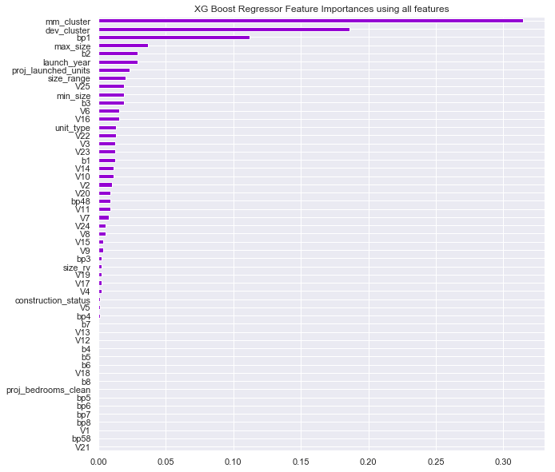

```python
fig,ax=plt.subplots(figsize=(10,10)) # Feature importance visualisation for all features fed into XG Boost Regressor
fig=plot_feature_importances (xg_reg_all, 'barh', 'XG Boost Regressor Feature Importances using all features','darkviolet', x1_train)
```

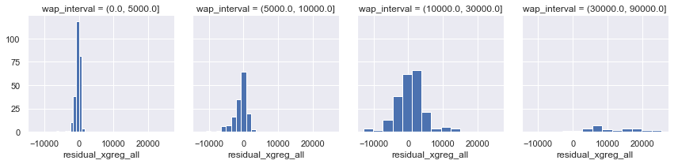

```python
g = sns.FacetGrid(df1, col="wap_interval")
g = g.map(plt.hist, "residual_xgreg_all")
```

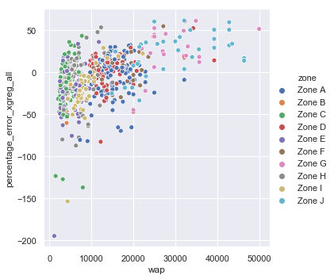

```python
sns.relplot(x="wap", y="percentage_error_xgreg_all", hue="zone", data=df1)
```

Notice how regularisation has reduced cases of overprediction above 100% compared to linear regression model?

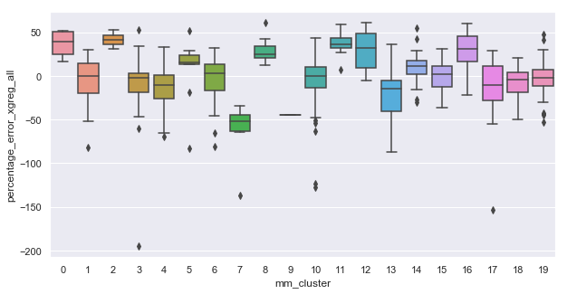

```python
f, ax = plt.subplots(figsize=(10,5))
sns.boxplot(x="mm_cluster", y="percentage_error_xgreg_all", data=df1)
```

If we feed all the features to a XG Boost regressor, the XG Boost regressor will overfit even more and show worse performance compared to a handful of features selected for the final model.

## 7. Random Forest Regressor of Final Model

Let's deploy a Random Forest Regressor and see how it performs.

```python
from sklearn.ensemble import RandomForestRegressor

rf = RandomForestRegressor(n_estimators=3000, n_jobs=5, random_state=5, max_depth=12)
rf.fit(x_train, y_train)
```

```
RandomForestRegressor(bootstrap=True, criterion='mse', max_depth=12,
           max_features='auto', max_leaf_nodes=None,
           min_impurity_decrease=0.0, min_impurity_split=None,
           min_samples_leaf=1, min_samples_split=2,
           min_weight_fraction_leaf=0.0, n_estimators=3000, n_jobs=5,
           oob_score=False, random_state=5, verbose=0, warm_start=False)
```

```python
print('Random Forest Regressor:',)
print(model_r2score (rf, x_test, y_test))
```

```
Random Forest Regressor:
0.8720659262266577
```

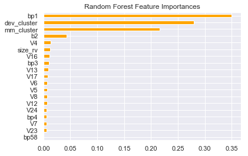

```python
plot_feature_importances (rf, 'barh', 'Random Forest Feature Importances','orange', x_train)
```

```python
compute_residual (rf, 'residual_rf', df1, x_test, y_test) # Residual statistics of Random Forest Regressor
```

```
count      656.000000
mean       668.830645
std       3833.341630
min     -11069.537722
25%       -688.724213
50%         22.658193
75%        789.791125
max      27881.910253
Name: residual_rf, dtype: float64
```

```python
# Percentage Error vs projects for Random Forest Regressor
percentage_error_projects (df1, 'residual_rf', 'percentage_error_rf','percentage_error_interval_rf')
```

|  | percentage_error_interval_rf | project_number | percentage_projects |
| --- | --- | --- | --- |
| 0 | (-inf, -30.0] | 66 | 10.060976 |
| 1 | (-30.0, -20.0] | 38 | 5.792683 |
| 2 | (-20.0, -10.0] | 77 | 11.737805 |
| 3 | (-10.0, 0.0] | 139 | 21.189024 |
| 4 | (0.0, 10.0] | 163 | 24.847561 |
| 5 | (10.0, 20.0] | 86 | 13.109756 |
| 6 | (20.0, 30.0] | 44 | 6.707317 |
| 7 | (30.0, inf] | 43 | 6.554878 |

```python
# Mean Absolute Percentage Error for Random Forest Regressor
print('MAPE of Random Forest Regressor:',np.absolute(df1['percentage_error_rf']).mean())
```

```
MAPE of Random Forest Regressor: 19.20338762532902
```

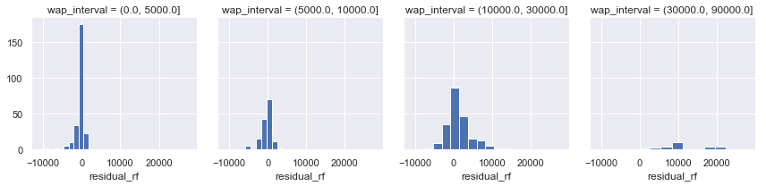

```python
g = sns.FacetGrid(df1, col="wap_interval")
g = g.map(plt.hist, "residual_rf")
```

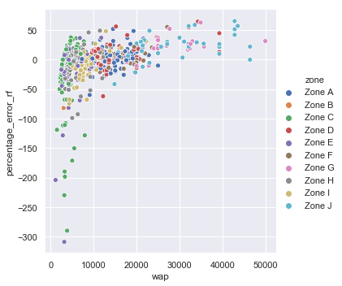

```python
sns.relplot(x="wap", y="percentage_error_rf", hue="zone", data=df1)
```

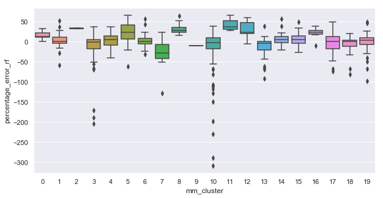

```python
f, ax = plt.subplots(figsize=(10,5))
sns.boxplot(x="mm_cluster", y="percentage_error_rf", data=df1)
```

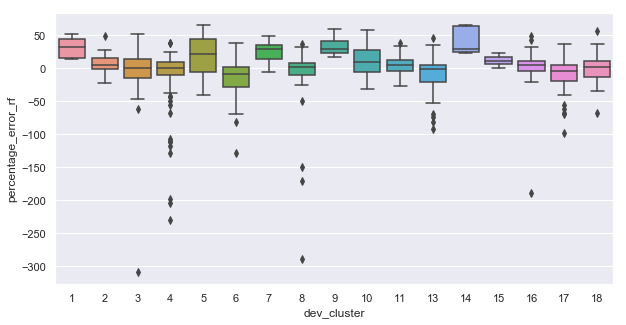

```python
f, ax = plt.subplots(figsize=(10,5))
sns.boxplot(x="dev_cluster", y="percentage_error_rf", data=df1)
```

## 8. Lasso Regression Model

```python
df4=pd.concat([df2, pd.get_dummies(df2['mm_cluster'],dtype=float),pd.get_dummies(df1['dev_cluster'],dtype=float), pd.get_dummies(df1['construction_status'],dtype=float)],axis=1)
df4=df4.drop(columns=['mm_cluster','dev_cluster'])
df4.head()
```

|  | log_wap | b2 | bp1 | bp3 | bp4 | bp58 | size_rv | V4 | V5 | V6 | ... | 11 | 13 | 14 | 15 | 16 | 17 | 18 | Completed | Pre Launch | Under Construction |
| --- | --- | --- | --- | --- | --- | --- | --- | --- | --- | --- | --- | --- | --- | --- | --- | --- | --- | --- | --- | --- | --- |
| 0 | 9.579418 | 5 | 0.954955 | 0.000000 | 0.0 | 0.0 | 1.383353 | -0.067081 | -0.185371 | -0.032546 | ... | 0.0 | 0.0 | 0.0 | 0.0 | 1.0 | 0.0 | 0.0 | 0.0 | 0.0 | 1.0 |
| 1 | 9.545526 | 98 | 0.000000 | 0.346667 | 0.0 | 0.0 | 0.372748 | 0.278550 | -0.111899 | 0.312749 | ... | 0.0 | 0.0 | 0.0 | 0.0 | 1.0 | 0.0 | 0.0 | 0.0 | 0.0 | 1.0 |
| 2 | 9.545526 | 98 | 0.000000 | 0.346667 | 0.0 | 0.0 | 0.372748 | 0.282199 | -0.090756 | 0.292134 | ... | 0.0 | 0.0 | 0.0 | 0.0 | 1.0 | 0.0 | 0.0 | 0.0 | 0.0 | 1.0 |
| 3 | 9.461644 | 13 | 0.891667 | 0.000000 | 0.0 | 0.0 | 1.187398 | 0.391827 | -0.249752 | 0.281397 | ... | 0.0 | 0.0 | 0.0 | 0.0 | 0.0 | 0.0 | 0.0 | 0.0 | 0.0 | 1.0 |
| 4 | 9.739884 | 22 | 0.030303 | 0.303030 | 0.0 | 0.0 | 1.519184 | 0.307399 | -0.107702 | 0.292808 | ... | 1.0 | 0.0 | 0.0 | 0.0 | 0.0 | 0.0 | 0.0 | 0.0 | 0.0 | 1.0 |

5 rows × 58 columns

```python
dept = 'log_wap'
indept = df4.columns != dept
x2 = df4.loc[:,indept]
y2 = df4[dept]
x2_train, x2_test, y2_train, y2_test = train_test_split(x2, y2, random_state=8)

from sklearn.linear_model import Lasso
lasso = Lasso(alpha=0.0001,max_iter=1000, tol=0.0001)
lasso.fit(x2_train, y2_train)
```

```
Lasso(alpha=0.0001, copy_X=True, fit_intercept=True, max_iter=1000,
   normalize=False, positive=False, precompute=False, random_state=None,
   selection='cyclic', tol=0.0001, warm_start=False)
```

```python
# cross validate
scores_lasso = cross_validate(lasso , x2_train, y2_train, cv=8,
                        return_train_score=True,
                        return_estimator=False)
scores_lasso = pd.DataFrame(scores_lasso)
scores_lasso
```

|  | fit_time | score_time | test_score | train_score |
| --- | --- | --- | --- | --- |
| 0 | 0.039943 | 0.000000 | 0.939977 | 0.946152 |
| 1 | 0.047935 | 0.000000 | 0.937380 | 0.946748 |
| 2 | 0.051929 | 0.003995 | 0.950702 | 0.944926 |
| 3 | 0.035951 | 0.000000 | 0.936555 | 0.946614 |
| 4 | 0.042996 | 0.000000 | 0.949936 | 0.944939 |
| 5 | 0.054398 | 0.003995 | 0.941735 | 0.945981 |
| 6 | 0.046616 | 0.008022 | 0.939641 | 0.946411 |
| 7 | 0.040181 | 0.000000 | 0.938427 | 0.946398 |

```python
print('Mean Test Score using Lasso Regression: ', scores_lasso ['test_score'].mean())
print('Mean Train Score using Lasso Regression: ', scores_lasso ['train_score'].mean())
```

```
Mean Test Score using Lasso Regression:  0.9417942398146517
Mean Train Score using Lasso Regression:  0.9460212348729389
```

```python
print('Lasso Regressor:',)
print(model_r2score (lasso, x2_test, y2_test))
```

```
Lasso Regressor:
0.9417465748995817
```

Let's investigate how model performance varies with values of regularisation parameter alpha.

[output not shown]

[output cut: 157 more lines]

[output not shown]

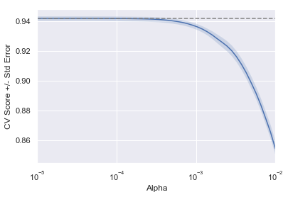

```python
from sklearn.model_selection import cross_val_score

# Create an array of alphas and lists to store scores
alpha_space = np.logspace(-5, -2, 50)
lasso_scores = []
lasso_scores_std = []

# Compute scores over range of alphas
for alpha in alpha_space:

    # Specify the alpha value to use: ridge.alpha
    lasso.alpha = alpha

    # Perform 10-fold CV: lasso_cv_scores again with a different sklearn library of course
    lasso_cv_scores = cross_val_score(lasso, x2_train, y2_train, cv=8)

    # Append the mean of lasso_cv_scores to lasso_scores
    lasso_scores.append(np.mean(lasso_cv_scores))

    # Append the std of lasso_cv_scores to lasso_scores_std
    lasso_scores_std.append(np.std(lasso_cv_scores))

# Use this function to create a plot
def display_plot(cv_scores, cv_scores_std):
    fig = plt.figure()
    ax = fig.add_subplot(1,1,1)
    ax.plot(alpha_space, cv_scores)

    std_error = cv_scores_std / np.sqrt(10)

    ax.fill_between(alpha_space, cv_scores + std_error, cv_scores - std_error, alpha=0.2)
    ax.set_ylabel('CV Score +/- Std Error')
    ax.set_xlabel('Alpha')
    ax.axhline(np.max(cv_scores), linestyle='--', color='.5')
    ax.set_xlim([alpha_space[0], alpha_space[-1]])
    ax.set_xscale('log')
    plt.show()

# Display the plot
display_plot(lasso_scores, lasso_scores_std)
```

Strategy for fine-tuning Lasso Regression model: small value of alpha and larger number of iterations.

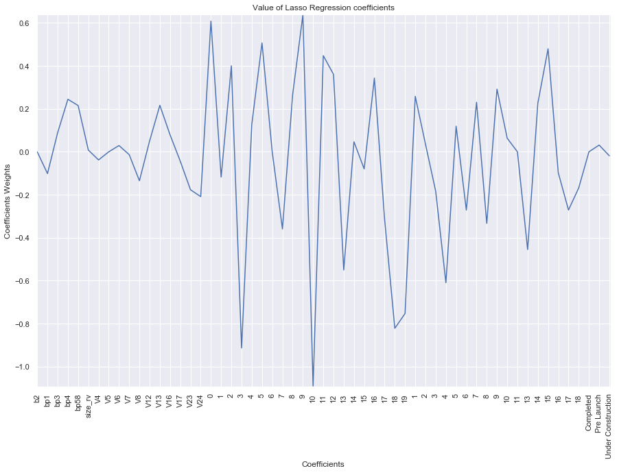

```python
# Plot the Lasso Regression coefficients importance
plt.figure(figsize=(15,10))
plt.plot(range(len(x2_train.columns)), lasso.coef_)
plt.xticks(range(len(x2_train.columns)), x2_train.columns, rotation=90)
plt.margins(0.002)
plt.xlabel('Coefficients')
plt.ylabel('Coefficients Weights')
plt.title('Value of Lasso Regression coefficients')
plt.show()
```

Let's look at how coefficient weights shrink to zero gradually as value of alpha is increased.

```
(2.5118864315095876e-07,
 3981071.705534961,
 -1.1809567622987123,
 0.7579947502186914)
```

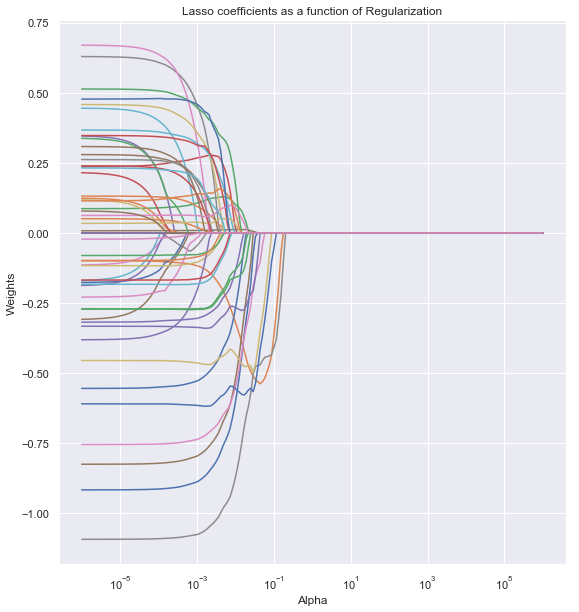

```python
coefs = []
alphas = np.logspace(-6, 6, 200)

#Save same dataframe containing lasso regressor features with different name as we are trying a wide different
#range of alphas
lasso_clone = Lasso(alpha=0.0001,max_iter=100000, tol=0.0001)

# Train the model with different regularisation strengths
for a in alphas:
    lasso_clone.set_params(alpha=a) #Alpha parameter variation
    lasso_clone.fit(x2_train, y2_train)
    coefs.append(lasso_clone.coef_)

# Display results
plt.figure(figsize=(20, 10))
plt.subplot(121)
ax = plt.gca()
ax.plot(alphas, coefs)
ax.set_xscale('log')
plt.xlabel('Alpha')
plt.ylabel('Weights')
plt.title('Lasso coefficients as a function of Regularization')
plt.axis('tight')
```

It can be inferred that shrinking of coefficients is drastic and takes place around a certain interval width of alpha.

```python
compute_residual (lasso, 'residual_lasso', df1, x2_test, y2_test) # Residual statistics of Lasso Regressor
```

```
count      656.000000
mean      -109.356764
std       2519.695140
min     -21519.742760
25%       -797.586718
50%        -34.814667
75%        587.517783
max      11794.802254
Name: residual_lasso, dtype: float64
```

```python
# Percentage Error vs projects for Random Forest Regressor
percentage_error_projects (df1, 'residual_lasso', 'percentage_error_lasso','percentage_error_interval_lasso')
```

|  | percentage_error_interval_lasso | project_number | percentage_projects |
| --- | --- | --- | --- |
| 0 | (-inf, -30.0] | 48 | 7.317073 |
| 1 | (-30.0, -20.0] | 40 | 6.097561 |
| 2 | (-20.0, -10.0] | 98 | 14.939024 |
| 3 | (-10.0, 0.0] | 148 | 22.560976 |
| 4 | (0.0, 10.0] | 170 | 25.914634 |
| 5 | (10.0, 20.0] | 106 | 16.158537 |
| 6 | (20.0, 30.0] | 32 | 4.878049 |
| 7 | (30.0, inf] | 14 | 2.134146 |

```python
# Mean Absolute Percentage Error for Lasso Regressor
print('MAPE of Lasso Regressor:',np.absolute(df1['percentage_error_lasso']).mean())
```

```
MAPE of Lasso Regressor: 14.015369215112184
```

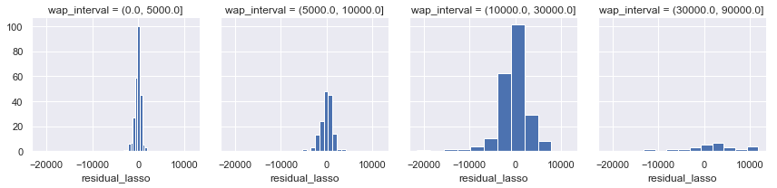

```python
sns.FacetGrid(df1, col="wap_interval").map(plt.hist, "residual_lasso")
```

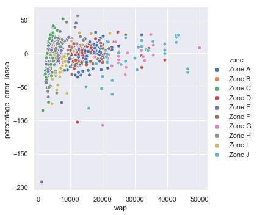

```python
sns.relplot(x="wap", y="percentage_error_lasso", hue="zone", data=df1)
```

Notice how the number of cases overpredicted by over 100% has decreased? For these specific cases, the amount of overpredictions has decreased as well with the help of regularisation. Regularisation has helped to weed out numerous multicorrelated predictor variables. Drastic improvement in model performance!

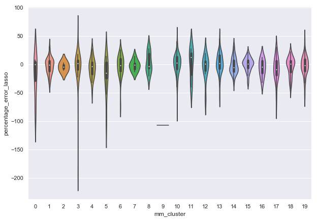

```python
f, ax = plt.subplots(figsize=(10,7))
sns.violinplot(x="mm_cluster", y="percentage_error_lasso", data=df1)
```

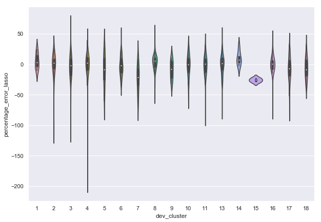

```python
f, ax = plt.subplots(figsize=(10,7))
sns.violinplot(x="dev_cluster", y="percentage_error_lasso", data=df1)
```

## 10. Conclusion / Key Insights

1. Micromarket and developer clusters show good variations in prices.
2. The final model shows high R-squared value of above 0.94 which indicates a good fit with minimised residuals.
3. Residual diagnostics of the base and final models show robust predictive models.
4. It has been so far easy to predict most of the projects with low errors in price predictions (low error percentage), another indication of a robust model. Most of the projects fell under lower price categories. Projects with higher errors in predictions occur by chances and occur less frequently.
5. Linear Regression outperforms both Extreme Gradient Boosting algorithm and Random Forest Regressor. The underlying data structure between chosen predictor variables and dependent variable is linear. Models with complexity greater than that of linear regression will capture variations and noise and thus perform relatively poorer in predicted real estate prices.
6. Significant time should be spent on hyperparameter tuning to maximise model performance using various combinations of parameters.
7. Features should be chosen carefully to avoid problems of multicollinearity and overfitting. They should be able to contribute to variations in dependent variable. Exploratory data analysis involving multivariate/bivariate plots and statistical tests should aid in that.
8. Regularisation has shrunk importance (i.e weights) of numerous multicorrelated predictor variables and improved model performance.
9. The predictive power of models degenerate over time. Backtesting helps us understand for how long a model will give accurate predictions.